# Developing Data Products Course: Pitch

2022-10-08

## The normal distribution

The *normal* distribution, or *Gaussian* distribution, is probably the most well-known distribution there is. It is defined by the **mean**, \(\mu\), and the **standard deviation**, \(\sigma\). The standard deviation is often also referred to as the **variance**, \(\sigma^2\), which relates to the spread of the distribution.

## The properties of the normal distribution

The *standard* normal distribution has a \(\mu=0\) and a \(\sigma=1\) (in red). However, all normal distributions are symmetrical about their mean regardless of their parameters.

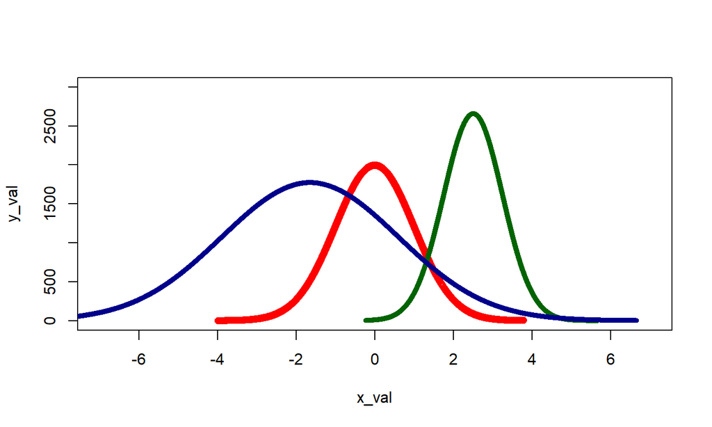

## 95% Confidence Interval

The 95% Confidence Interval in a normal distribution refers to the range of values that one can be 95% confident \(\mu\) actually takes. This can be accomplished by calculating the quantile range between the 2.5th and 97.5th percentile as shown below. In the standard normal, this is approximately 2 standard deviations from the mean (-2, 2).

```
## [1] -1.959964  1.959964
```

## The shiny application

The shiny application built can be accessed here:

https://sgb67.shinyapps.io/jhu-ddp-project/

It allows to display the histogram of a custom-made normal distribution. The corresponding normal distribution, mean, and 95% CI can also be plotted. The actual interval is shown in the main panel. For the server.R and ui.R files, click here:

https://github.com/sgb67/JHU-DDP-assignments